# Principal Components Analysis (PCA) and Exploratory Factor Analysis (EFA)

In the first part of this homework assignment, you’ll perform PCA on a US crime data set and explore the relationships between the variables in the data. In the second part, you’ll use EFA to analyze the responses from a survey on managerial skills.

## US Crime Data Analysis (35 points)

First, load the data provided in the uscrime.txt file into an R data frame and display it as below (5 points). The dataset contains the following variables:

R: Crime rate: # of offenses reported to police per million population

Age: The number of males of age 14-24 per 1000 population

Ed: Mean # of years of schooling x 10 for persons of age 25 or older

Ex0: 1960 per capita expenditure on police by state and local government

Ex1: 1959 per capita expenditure on police by state and local government

LF: Labor force participation rate per 1000 civilian urban males age 14-24

M: The number of males per 1000 females

N: State population size in hundred thousands

U1: Unemployment rate of urban males per 1000 of age 14-24

U2: Unemployment rate of urban males per 1000 of age 35-39

W: Median value of transferable goods and assets or family income in tens of $

X: The number of families per 1000 earning below 1/2 the median income

Once loaded, the data should look like:

```
##        R Age  Ed Ex0 Ex1  LF    M   N  U1 U2   W   X
## 1   79.1 151  91  58  56 510  950  33 108 41 394 261
## 2  163.5 143 113 103  95 583 1012  13  96 36 557 194
## 3   57.8 142  89  45  44 533  969  18  94 33 318 250
## 4  196.9 136 121 149 141 577  994 157 102 39 673 167
## 5  123.4 141 121 109 101 591  985  18  91 20 578 174
## 6   68.2 121 110 118 115 547  964  25  84 29 689 126
## 7   96.3 127 111  82  79 519  982   4  97 38 620 168
## 8  155.5 131 109 115 109 542  969  50  79 35 472 206
## 9   85.6 157  90  65  62 553  955  39  81 28 421 239
## 10  70.5 140 118  71  68 632 1029   7 100 24 526 174
## 11 167.4 124 105 121 116 580  966 101  77 35 657 170
## 12  84.9 134 108  75  71 595  972  47  83 31 580 172
## 13  51.1 128 113  67  60 624  972  28  77 25 507 206
## 14  66.4 135 117  62  61 595  986  22  77 27 529 190
```

[output cut: 33 more lines]

Now perform PCA with scaling, and plot the resulting Scree plot (10 points).

```
## Standard deviations:
##  [1] 2.2292902 1.5270237 1.3527914 1.1013981 0.7770701 0.5649796 0.4949622
##  [8] 0.4700725 0.3582280 0.2773785 0.2364407 0.0719401
##
## Rotation:
##             PC1         PC2          PC3         PC4          PC5
## R    0.26685963  0.08673898 -0.116821578  0.64689323 -0.088574854
## Age -0.31162886 -0.07141851 -0.160223186  0.43938861 -0.313768592
## Ed   0.34242058 -0.32422100  0.109941139 -0.10235683 -0.017166226
## Ex0  0.40393369  0.15691222 -0.152718666  0.15791580 -0.146995179
## Ex1  0.40497071  0.15166825 -0.156179671  0.12915958 -0.181184557
## LF   0.15298518 -0.48983303 -0.002055818  0.16214051  0.608179770
## M    0.09777702 -0.35558275  0.453041959  0.39008302  0.009873998
## N    0.18259610  0.39194925 -0.288349349  0.02838305  0.611000190
## U1   0.02570843  0.24164638  0.657892543  0.02500586  0.078895617
## U2   0.05753086  0.49216742  0.416886848  0.10981777  0.080150339
## W    0.42156549 -0.03062254  0.020902473 -0.14357819 -0.117548506
## X   -0.37318024  0.11433546 -0.073677465  0.35186709  0.263070432
##             PC6           PC7         PC8         PC9        PC10
## R   -0.25261335  0.4778158919  0.00833614 -0.19481698  0.27537438
## Age  0.65334808  0.0219074509 -0.33727878  0.11583879 -0.08904480
## Ed   0.17512474  0.5972371852  0.24987837  0.26950172 -0.43505518
## Ex0 -0.05751002 -0.3338959261  0.03570042  0.33192761 -0.02003496
## Ex1 -0.04551056 -0.3182562134  0.06867715  0.35903369 -0.06884604
## LF  -0.08233415 -0.1028063231 -0.50280458  0.24104658  0.10673679
## M    0.11599050 -0.4222481274  0.36470849 -0.34917502 -0.22289082
## N    0.49971878  0.0009399851  0.23802975 -0.18263490 -0.07451698
## U1   0.26132012  0.0955520294  0.09228313  0.34766157  0.53709218
## U2  -0.15793770  0.0559828359 -0.47154888 -0.07791235 -0.55286517
## W    0.11662316 -0.0024477084 -0.25434122 -0.53842433  0.24194757
## X   -0.31062910  0.0247489509  0.28230551  0.08181438 -0.05033295
##             PC11          PC12
## R   -0.272936635  2.878398e-02
## Age  0.134592638 -6.236659e-03
## Ed   0.202850003 -4.379262e-02
## Ex0  0.069423774 -7.147606e-01
## Ex1  0.110710462  6.965033e-01
## LF   0.001246253  2.871379e-02
## M   -0.100514013  5.014691e-03
## N   -0.101854676  1.008454e-02
## U1   0.076936911  9.124091e-03
## U2  -0.003785031  1.214733e-03
## W    0.599783075 -3.997247e-06
## X    0.680450937 -1.338735e-02
```

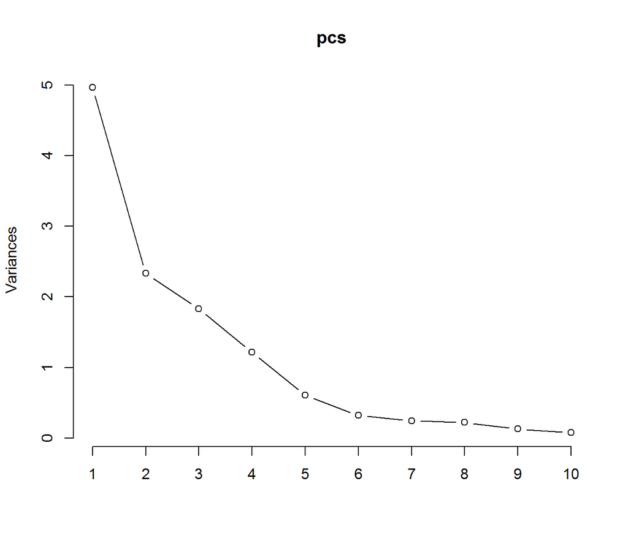

**Answer the following questions:** *What does the scree plot tell you? (2 points)

This scree plot shows that 6 of those factors explain most of the variability because the line starts to straighten after factor 6. The remaining factors explain a very small proportion of the variability and are likely unimportant. And there are 4 factors with an eigenvalue > 1, which explain more variance than a single observed variable.

*What can you say about the data from the scree plot? (3 points)

Draw a biplot of the PCA results (5 points)

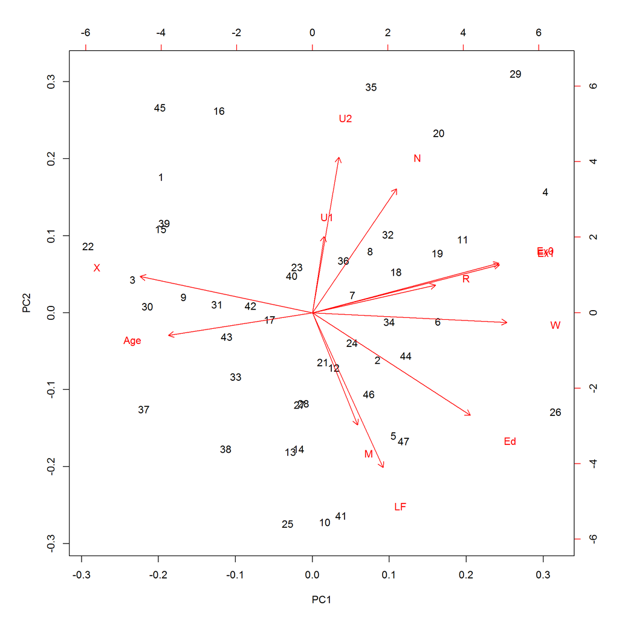

**Answer questions:** * (2 points) From the biplot, what can you say about Ex0 (1960 per capita police expenditure) and Ex1 (1959 per capita police expenditure)?

EX0 and Ex1 are almost the same.

- (2 points) From the biplot, what can you say about R (crime rate) and Ex0 (1960 per capita police expenditure)?

R and Ex0 are highly correlated.

- (2 points) From the biplot, what can you say about W (median assets/income) and Age (proportion of males 14-24)?

- (4 points) U2 and U1 point in almost exactly the same direction. Does this mean they are highly correlated? Why? Plot a scatterplot of these two variables and compute the Pearson’s correlation coeffecient to justify your answer.

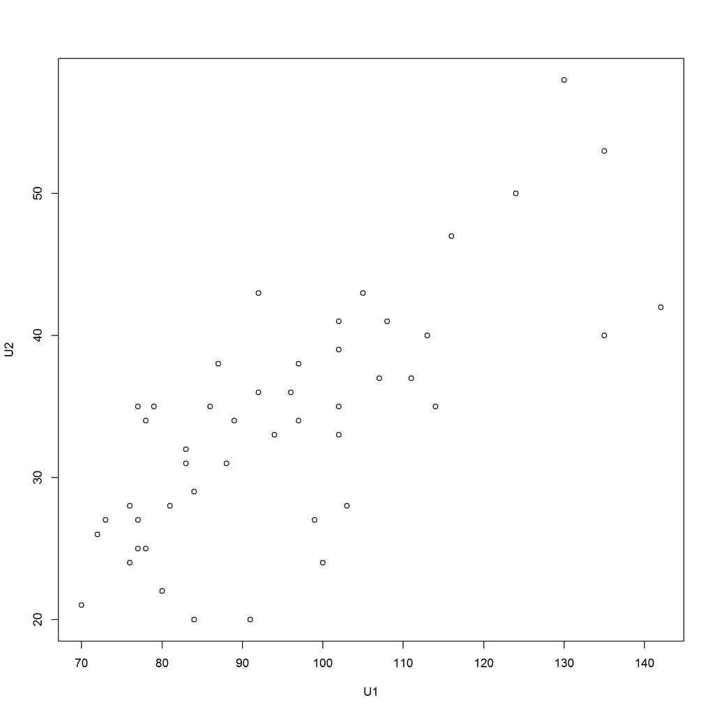

```
##           U1        U2
## U1 1.0000000 0.7459248
## U2 0.7459248 1.0000000
```

Yes, we can say that they are highly correlated. From the scatterplot, we can find that the points distribute on a line basically. And the Pearson’s correlation coeffecient, 0.746 shows also shows high correlation.

## Managerial Skills Survey Analysis (30 points)

The included CSV file “manage.csv” contains survey data of these 11 questions:

1. I show confidence in my staff
2. I let my staff know they are doing well
3. I give feedback to staff on how well they are working
4. I would personally compliment staff if they did outstanding work
5. I believe in setting goals and achieving them
6. I achieve the things I want to get done in a day
7. I never try to put off until tomorrow what I can finish today
8. I plan the use of my time well
9. I remain clear headed when too many demands are made upon me
10. I rarely overlook important factors when plans are made
11. I handle complex problems efficiently

We can view each question as an apparent skill. The question we seek to answer through EFA is: Are there underlying fundamental “latent” skills that “produce” or “explain” these 11 observed skills?

First, load the data into a R data frame. You can’t do EFA on this data frame directly, because the answers to these survey questions are not numerical. You’ll need to convert the data frame into a numeric data frame according to the following scale (6 points):

| Survey Answer | Corresponding Numeric Value |
| --- | --- |
| VERY LITTLE EXTENT | 1 |
| LITTLE EXTENT | 2 |
| SOME EXTENT | 3 |
| MODERATE EXTENT | 4 |
| CONSIDERABLE EXTENT | 5 |
| GREAT EXTENT | 6 |
| TO A VERY GREAT EXTENT | 7 |

```
##
## Call:
## factanal(x = manage, factors = 1, rotation = "promax")
##
## Uniquenesses:
##    q1    q2    q3    q4    q5    q6    q7    q8    q9   q10   q11
## 0.722 0.475 0.650 0.517 0.684 0.615 0.545 0.610 0.682 0.557 0.662
##
## Loadings:
##     Factor1
## q1  0.527
## q2  0.724
## q3  0.592
## q4  0.695
## q5  0.562
## q6  0.621
## q7  0.674
## q8  0.624
## q9  0.564
## q10 0.665
## q11 0.582
##
##                Factor1
## SS loadings      4.281
## Proportion Var   0.389
##
## Test of the hypothesis that 1 factor is sufficient.
## The chi square statistic is 189.71 on 44 degrees of freedom.
## The p-value is 5.28e-20
```

```
##
## Call:
## factanal(x = manage, factors = 2, rotation = "promax")
##
## Uniquenesses:
##    q1    q2    q3    q4    q5    q6    q7    q8    q9   q10   q11
## 0.574 0.238 0.560 0.401 0.614 0.339 0.428 0.249 0.724 0.589 0.686
##
## Loadings:
##     Factor1 Factor2
## q1   0.752  -0.183
## q2   0.951  -0.134
## q3   0.690
## q4   0.806
## q5   0.118   0.541
## q6  -0.135   0.891
## q7           0.692
## q8  -0.213   0.985
## q9   0.402   0.169
## q10  0.456   0.247
## q11  0.232   0.384
##
##                Factor1 Factor2
## SS loadings      3.106   2.828
## Proportion Var   0.282   0.257
## Cumulative Var   0.282   0.539
##
## Factor Correlations:
##         Factor1 Factor2
## Factor1    1.00    0.63
## Factor2    0.63    1.00
##
## Test of the hypothesis that 2 factors are sufficient.
## The chi square statistic is 69.68 on 34 degrees of freedom.
## The p-value is 0.000296
```

```
##
## Call:
## factanal(x = manage, factors = 3, rotation = "promax")
##
## Uniquenesses:
##    q1    q2    q3    q4    q5    q6    q7    q8    q9   q10   q11
## 0.576 0.123 0.570 0.437 0.570 0.338 0.395 0.263 0.302 0.469 0.559
##
## Loadings:
##     Factor1 Factor2 Factor3
## q1  -0.170   0.586   0.200
## q2           1.047  -0.145
## q3           0.620
## q4           0.698
## q5   0.599   0.242  -0.189
## q6   0.843
## q7   0.723   0.180  -0.100
## q8   0.895  -0.193   0.104
## q9          -0.118   0.936
## q10  0.121   0.160   0.539
## q11  0.243           0.539
##
##                Factor1 Factor2 Factor3
## SS loadings      2.501   2.488   1.583
## Proportion Var   0.227   0.226   0.144
## Cumulative Var   0.227   0.454   0.597
##
## Factor Correlations:
##         Factor1 Factor2 Factor3
## Factor1   1.000  -0.532   0.653
## Factor2  -0.532   1.000  -0.519
## Factor3   0.653  -0.519   1.000
##
## Test of the hypothesis that 3 factors are sufficient.
## The chi square statistic is 27.58 on 25 degrees of freedom.
## The p-value is 0.327
```

Now perform exploratory factor analysis with “promax” rotation. Experiment with a minimum of 1,2 and 3 factors. Show the outputs of the factor analysis (12 points).

Can you find a set of factors that have “simple” structure (e.g. according to Thurstone’s criteria covered in class) while fitting the data well? Include a justification for your choice (6 points) Give your interpretation of each factor (6 points)?

The experiment with 3 factors shows well performance while fitting data, given the p-value is 0.327>0.05 and the factor correlations. According to Thurstone criteria, we can find the set of factors that have “simple” structure, as well as the interpretations: